# CIND 123 - Data Analytics: Basic Methods

# Assignment 3 (10%)

### CIND 123-DHA Student ID: 501068792

## Instructions

Use RStudio for this assignment. Complete the assignment by inserting your R code wherever you see the string “#INSERT YOUR ANSWER HERE”.

Submit **both** the rmd and generated output files. Failing to submit both files will be subject to mark deduction.

## Sample Question and Solution

Use `seq()` to create the vector $(2,4,6,\ldots,20)$.

```r
#Insert your code here.
seq(2,20,by = 2)
```

```
##  [1]  2  4  6  8 10 12 14 16 18 20
```

## Question 1

Use the following commands to install the `airquality` dataset and load the `datasets` package into your session.

```r
#install.packages("datasets")
library(datasets)
data(airquality)
str(airquality)
```

```
## 'data.frame':    153 obs. of  6 variables:
##  $ Ozone  : int  41 36 12 18 NA 28 23 19 8 NA ...
##  $ Solar.R: int  190 118 149 313 NA NA 299 99 19 194 ...
##  $ Wind   : num  7.4 8 12.6 11.5 14.3 14.9 8.6 13.8 20.1 8.6 ...
##  $ Temp   : int  67 72 74 62 56 66 65 59 61 69 ...
##  $ Month  : int  5 5 5 5 5 5 5 5 5 5 ...
##  $ Day    : int  1 2 3 4 5 6 7 8 9 10 ...
```

1. Use a histogram to assess the normality of the `Ozone` variable, then explain why it does not appear normally distributed.

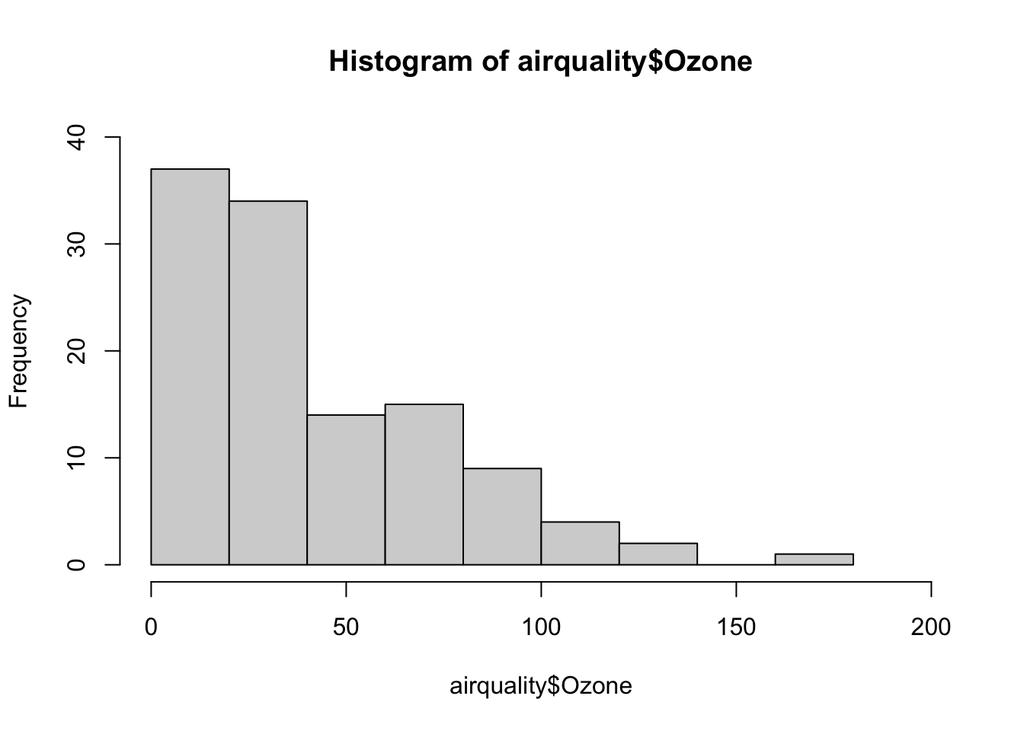

```r
hist(airquality$Ozone,
     xlim = c(0,200),
     ylim = c(0,40),)
```

```r
#The dataframe only contains 153 samples, some of which are NAs. It could be that the sample size is not large enough for the data points to appear as normally distributed (i.e., easily affected by extreme values)
```

2. Create a set of boxplots that shows the distribution of `Ozone` in each month. Use different colors for each month.

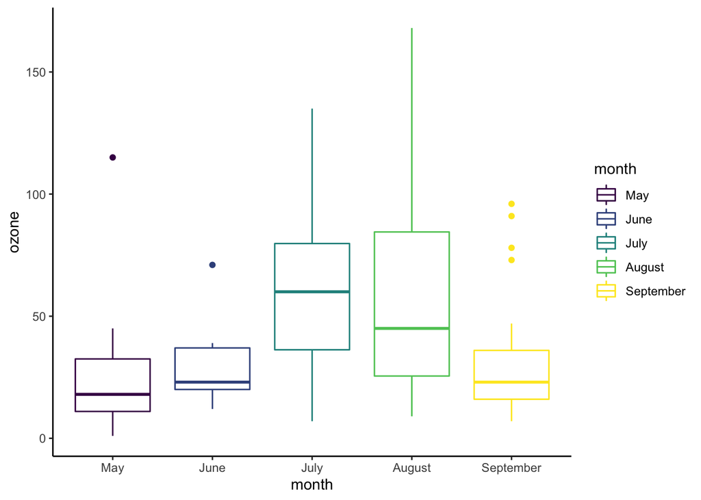

```r
library(ggplot2)
airqualitynonas <- na.omit(airquality)
ozone <- airqualitynonas$Ozone
month <- factor(airqualitynonas$Month, order = TRUE, labels = c("May", "June", "July", "August", "September"))
ggplot(airqualitynonas, aes(x=month, y=ozone, color=month)) +
geom_boxplot()+
theme_classic()
```

Use the following commands to install the `marketing` dataset and load the `datarium` package into your session.

```r
#install.packages("datarium")
library(datarium)
data("marketing", package = "datarium")
str(marketing)
```

```
## 'data.frame':    200 obs. of  4 variables:
##  $ youtube  : num  276.1 53.4 20.6 181.8 217 ...
##  $ facebook : num  45.4 47.2 55.1 49.6 13 ...
##  $ newspaper: num  83 54.1 83.2 70.2 70.1 ...
##  $ sales    : num  26.5 12.5 11.2 22.2 15.5 ...
```

1. Find the covariance between the `Sales` and the advertising budget of `newspaper`. Comment on the output, in terms of the strength and direction of the relationship.

```r
cov(marketing$sales, marketing$newspaper, method = "pearson")
```

```
## [1] 37.3556
```

```r
#We know that the two variables have a positive correlation because the covariance is a positive number. But because the covariance value is not standardized, it is difficult to determine the strength of the two variable. To determine the strengh of a linear relationship, we will need to calculate the correlation instead, which ranged from -1 to 1, with -1 showing a perfect negative linear relationship, 1 showing a perfect positive linear relationship, and 0 being no linear relationship at all.
```

2. Plot the `Sales` as a function of the `Youtube` variable using a scatterplot, then graph the least-square line on the same plot. Hint: You may use the `ggplot()` function from `ggplot2` package.

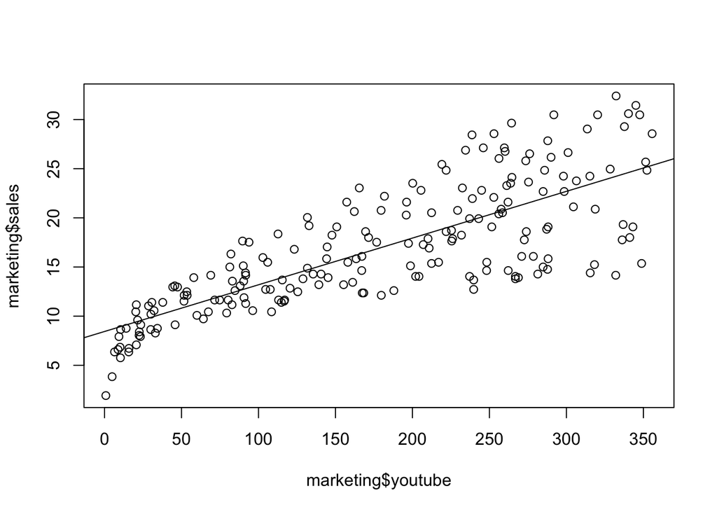

```r
plot(marketing$youtube, marketing$sales)
abline(lm(sales ~ youtube, data=marketing))
```

3. Use the regression line to predict the `Sales` amount when `newspaper` budget is `$136.80K`. Comment on the difference between the output and the expected value.

```r
slmodel <- lm(sales~newspaper, data=marketing)
c<-predict(slmodel,data.frame(newspaper=136.80))
c
```

```
##       1
## 22.3037
```